# R Notebook

# Frame

1. Maximum number of tourists travelling to India are from which country?
2. Predict the number of tourists traveling to India for the year 2011 from that country.

# Aquire

The data is in datafile.csv, aquired from https://data.gov.in/catalog/number-foreign-tourists-indi

```r
# Reading the csv to dataframe
df <- read.csv("datafile.csv")

# view the structure of dataframe
str(df)
```

```
## 'data.frame':    88 obs. of  12 variables:
##  $ Nationality: Factor w/ 70 levels "Afghanistan",..: 10 68 46 64 2 9 39 46 64 4 ...
##  $ Region     : Factor w/ 12 levels " EASTERN EUROPE",..: 9 9 9 9 7 7 7 7 7 12 ...
##  $ X2001      : int  88600 329147 NA 417747 2906 3819 3473 11727 21925 17787 ...
##  $ X2002      : int  93598 348182 NA 441780 1359 3622 3105 9586 17672 13801 ...
##  $ X2003      : int  107671 410803 NA 518474 1805 4528 3563 11758 21654 16903 ...
##  $ X2004      : int  135884 526120 NA 662004 2799 7397 4570 13399 28165 21093 ...
##  $ X2005      : int  157643 611165 NA 768808 3313 7005 5398 19870 35586 27187 ...
##  $ X2006      : int  176567 696739 NA 873306 4493 9148 6502 18602 38745 28045 ...
##  $ X2007      : int  208214 799062 NA 1007276 4992 10788 8299 18240 42319 26692 ...
##  $ X2008      : int  222364 804933 NA 1027297 5087 11530 9272 17616 43505 25900 ...
##  $ X2009      : int  224069 827140 NA 1051209 6011 13964 8185 18444 46604 27930 ...
##  $ X2010      : int  242372 931292 NA 1173664 7626 15219 10458 29425 62728 32620 ...
```

```r
View(df)
```

# Refine and Transform

- I will remove the rows with Others and Total in Nationality column

```r
library(dplyr)
library(tidyr)
df <- df %>%
    filter(Nationality != "Others", Nationality != "Total",
           Nationality != "STATELESS")
tail(df)
```

```
##    Nationality      Region X2001 X2002 X2003 X2004  X2005  X2006  X2007
## 62   Hong Kong   EAST ASIA   918   581  1070  1965   1908   1466    914
## 63       Japan   EAST ASIA 80634 59709 77996 96851 103082 119292 145538
## 64       Korea   EAST ASIA 29685 31552 36982 49314  53585  71920  85292
## 65   Australia AUSTRALASIA 52691 50743 58730 81608  96258 109867 135925
## 66 New Zealand AUSTRALASIA 11700 10811 13283 16762  20463  23493  27498
## 67        Fiji AUSTRALASIA  1422  1499  1519  2003   2326   2412   2635
##     X2008  X2009  X2010
## 62    519   1396   1507
## 63 145352 124756 168019
## 64  79824  70489  95612
## 65 146209 149074 169647
## 66  29261  30876  37024
## 67   2129   2031   2508
```

- Remove the Region column as we are only interested in Nationality

```r
df <- subset(df, select = -c(Region))
tail(df)
```

```
##    Nationality X2001 X2002 X2003 X2004  X2005  X2006  X2007  X2008  X2009
## 62   Hong Kong   918   581  1070  1965   1908   1466    914    519   1396
## 63       Japan 80634 59709 77996 96851 103082 119292 145538 145352 124756
## 64       Korea 29685 31552 36982 49314  53585  71920  85292  79824  70489
## 65   Australia 52691 50743 58730 81608  96258 109867 135925 146209 149074
## 66 New Zealand 11700 10811 13283 16762  20463  23493  27498  29261  30876
## 67        Fiji  1422  1499  1519  2003   2326   2412   2635   2129   2031
##     X2010
## 62   1507
## 63 168019
## 64  95612
## 65 169647
## 66  37024
## 67   2508
```

```r
length(unique(df$Nationality))
```

```
## [1] 67
```

```r
str(df)
```

```
## 'data.frame':    67 obs. of  11 variables:
##  $ Nationality: Factor w/ 70 levels "Afghanistan",..: 10 68 2 9 39 4 7 14 18 19 ...
##  $ X2001      : int  88600 329147 2906 3819 3473 17787 18851 14531 8186 102434 ...
##  $ X2002      : int  93598 348182 1359 3622 3105 13801 13945 10230 7673 78194 ...
##  $ X2003      : int  107671 410803 1805 4528 3563 16903 17309 11327 8001 97654 ...
##  $ X2004      : int  135884 526120 2799 7397 4570 21093 24007 15805 12525 131824 ...
##  $ X2005      : int  157643 611165 3313 7005 5398 27187 25596 20170 16258 152258 ...
##  $ X2006      : int  176567 696739 4493 9148 6502 28045 29156 21592 22860 175345 ...
##  $ X2007      : int  208214 799062 4992 10788 8299 26692 34207 28347 34364 204827 ...
##  $ X2008      : int  222364 804933 5087 11530 9272 25900 36277 34253 29223 207802 ...
##  $ X2009      : int  224069 827140 6011 13964 8185 27930 34759 30857 24874 196462 ...
##  $ X2010      : int  242372 931292 7626 15219 10458 32620 37709 35541 24089 225232 ...
```

```r
# Add summary column
df$summary = df$X2001 + df$X2002 + df$X2003 + df$X2004 + df$X2005 + df$X2006 +                      df$X2007 + df$X2008 + df$X2009 + df$X2010

# Arrange in descending order
df <- df %>% arrange(desc(summary))
dfTop10 <- df %>% top_n(10)
dfTop10
```

```
##    Nationality  X2001  X2002  X2003  X2004  X2005  X2006  X2007  X2008
## 1       U.S.A. 329147 348182 410803 526120 611165 696739 799062 804933
## 2         U.K. 405472 387846 430917 555907 651083 734240 796191 776530
## 3   Bangladesh 431312 435867 454611 477446 456371 484401 480240 541884
## 4    Sri Lanka 112813 108008 109098 128711 136400 154813 204084 218805
## 5       Canada  88600  93598 107671 135884 157643 176567 208214 222364
## 6       France 102434  78194  97654 131824 152258 175345 204827 207802
## 7      Germany  80011  64891  76868 116679 120243 156808 184195 204344
## 8        Japan  80634  59709  77996  96851 103082 119292 145538 145352
## 9    Australia  52691  50743  58730  81608  96258 109867 135925 146209
## 10   Malayasia  57869  63748  70750  84390  96276 107286 112741 115794
##     X2009  X2010 summary
## 1  827140 931292 6284583
## 2  769251 759494 6266931
## 3  468899 431962 4662993
## 4  239995 266515 1679242
## 5  224069 242372 1656982
## 6  196462 225232 1572032
## 7  191616 227720 1423375
## 8  124756 168019 1121229
## 9  149074 169647 1050752
## 10 135343 179077 1023274
```

# Explore

Display bar chart of maximum number of tourists

```r
library(ggplot2)

countryBarPlot <- ggplot(dfTop10) +
    aes(reorder(Nationality, summary), weight = summary, fill = summary) +
    xlab("Country") +
    ylab("Number of Tourists") +
    theme(axis.text.x = element_text(angle = 90, hjust = 1)) +
    geom_bar()


library(plotly)
ggplotly(countryBarPlot)
```

[interactive chart not shown]

Answering the question:

We can clearly see from the graph that maximum number of tourists are from **U.S.A.** in between the years 2001 to 2010, followed by **U.K.**

# Model

- Plot a scatter plot to view the relation

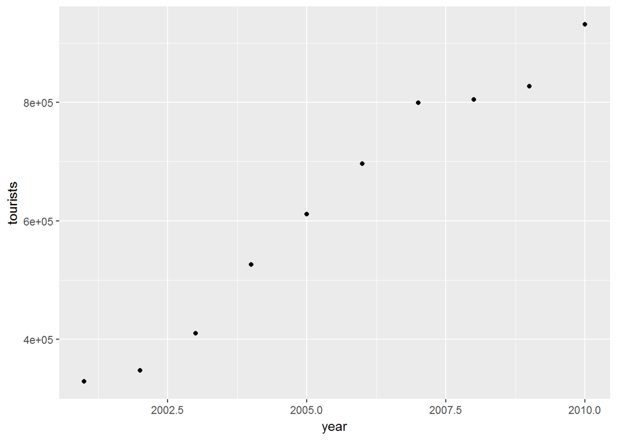

```r
usaData <- data.frame(year=c(2001:2010), tourists=as.numeric(dfTop10[1,2:11]))

p <- ggplot(usaData) +
    aes(year, tourists)
p + geom_point()
```

- Try to fit linear regression

```r
model1 <- lm(tourists~year, data = usaData)
model1
```

```
##
## Call:
## lm(formula = tourists ~ year, data = usaData)
##
## Coefficients:
## (Intercept)         year
##  -140936274        70588
```

```r
summary(model1)
```

```
##
## Call:
## lm(formula = tourists ~ year, data = usaData)
##
## Residuals:
##    Min     1Q Median     3Q    Max
## -48377 -28616   1774  18252  64721
##
## Coefficients:
##               Estimate Std. Error t value Pr(>|t|)
## (Intercept) -140936274    8301672  -16.98 1.47e-07 ***
## year             70588       4139   17.05 1.42e-07 ***
## ---
## Signif. codes:  0 '***' 0.001 '**' 0.01 '*' 0.05 '.' 0.1 ' ' 1
##
## Residual standard error: 37600 on 8 degrees of freedom
## Multiple R-squared:  0.9732, Adjusted R-squared:  0.9699
## F-statistic: 290.8 on 1 and 8 DF,  p-value: 1.421e-07
```

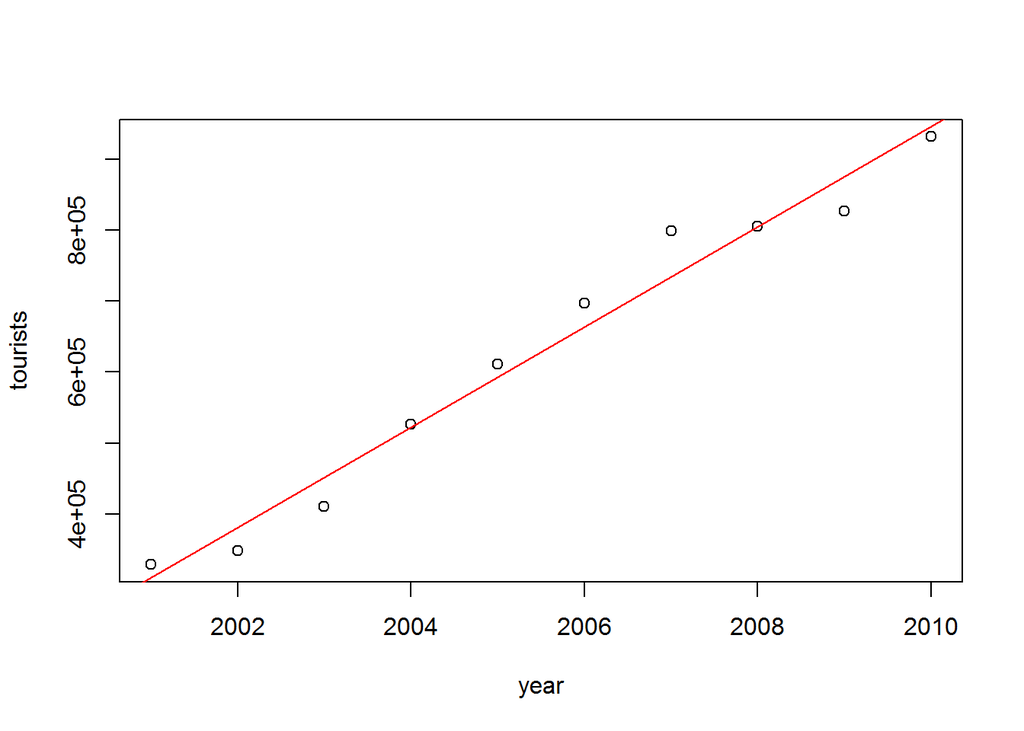

```r
# Notice that r2 is close to 1, so it looks like good fit

plot(tourists~year, data = usaData)
abline(model1, col = "red")
```

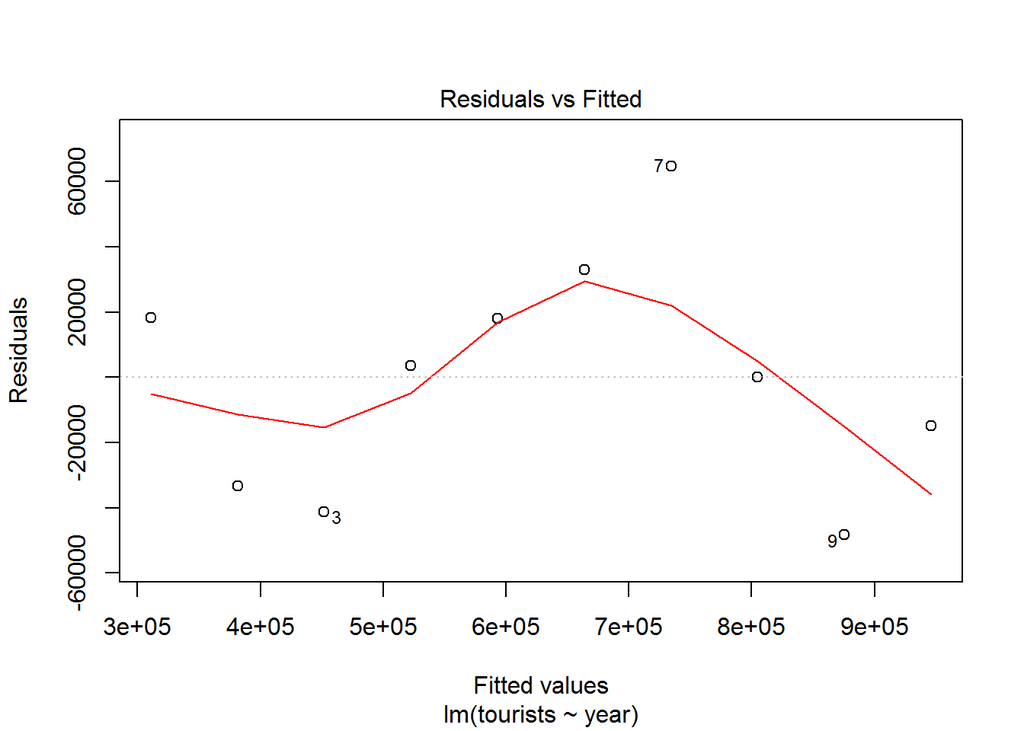

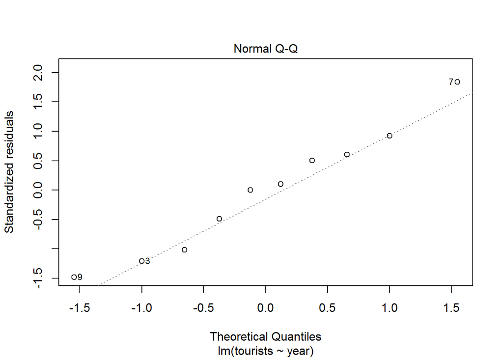

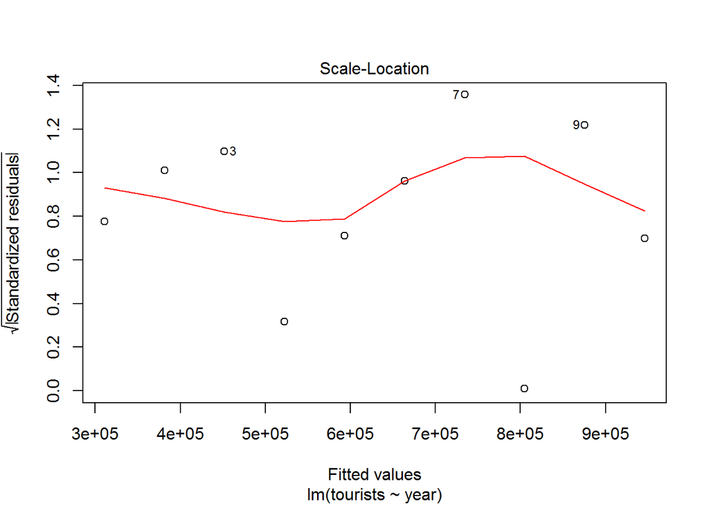

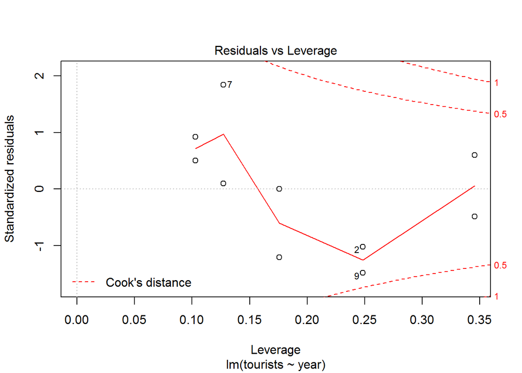

```r
plot(model1)
```

```r
# Predicting the values
p1 <- predict(model1, data.frame(year=c(2011:2014)))
predictedDf <- data.frame(year=2011:2014, tourists=p1)
predictedDf
```

```
##   year tourists
## 1 2011  1016694
## 2 2012  1087282
## 3 2013  1157870
## 4 2014  1228458
```

- From **predictedDf** we can predict that **1016694** tourists are going to come to India from USA in the year 2011.

# Communicate

The following are the answers to the framed question:

1. The maximum number of tourists are from **U.S.A.** in between the years 2001 to 2010, followed by **U.K.**
2. **1016694** tourists are going to come to India from USA in the year 2011.

Do check out my github repo git@github.com:dalonlobo/art-of-datascience.git, for my other work in this field.